# ButchR

Andres Quintero, Sebastian Steinhauser & Daniel Huebschmann

15.07.2020

# Contents

```r
library(BiocStyle)
library(ButchR)
library(knitr)
library(ComplexHeatmap)
library(viridis)
library(tidyverse)
```

# 1 Introduction

**NMF** (**nonnegative matrix factorization**) is a matrix decomposition method. A description of the algorithm and it’s implementation can be found e.g. in (Lee and Seung 1999). In 2003, Brunet et al. applied NMF to gene expression data (Brunet et al. 2003). In 2010, *NMF*, an R package implementing several NMF solvers was published (Gaujoux and Seoighe 2010). NMF basically solves the problem as illustrated in the following figure (Image taken from https://en.wikipedia.org/wiki/Non-negative_matrix_factorization):

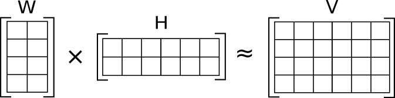

NMF

In 2015, Mejia-Roa et al. introduced an implementation of an NMF-solver in CUDA, which lead to significant reduction of computation times by making use of massive parallelisation on GPUs (Mejia-Roa et al. 2015). Other implementations of NMF-solvers on GPUs exist.

It is the pupose of the package `ButchR` described here to provide wrapper functions in R to these NMF-solvers in TensorFlow. Massive parallelisation not only leads to faster algorithms, but also makes the benefits of NMF accessible to much bigger matrices. Furthermore, functions for estimation of the optimal factorization rank and post-hoc feature selection are provided.

# 2 The ButchR package

The matrix decomposition results are stored in an S4 object called `ButchR_NMF`. `ButchR` provides functions to access the best factorzation after $n$ initailization $W$ and $H$ matrices for a given factorzation rank.

A crucial step in data analysis with NMF is the determination of the optimal factorization rank, i.e. the number of columns of the matrix $W$ or equivalently the number of rows of the matrix $H$. No consensus method for an automatic evaluation of the optimal factorization rank has been found to date. Instead, the decomposition is usually performed iteratively over a range of possible factorization ranks and different quality measures are computed for every tested factorization ranks. Many quality measures have been proposed:

- The `Frobenius reconstruction error`, i.e. the Frobenius norm of the residuals of the decomposition: $||W \cdot H - V||_{F}$
- Criteria to assess the stability of the decomposition:
  - The `cophenetic correlation coefficient`
  - An `Amari type distance`
  - `Silhouette values` over clusters of patterns extracted iteratively at the same factorization rank

The package `ButchR` provides a function to visualize all factorization metrics.

# 3 Example: leukemia data

Preparations

Load the example data

```r
data(leukemia)
```

Now we are ready to start an NMF analysis.

## 3.1 NMF analysis

### 3.1.1 Call wrapper function

The wrapper function for the NMF solvers in the ButchR package is `runNMFtensor_lite`. It is called as follows:

```r
k_min <- 2
k_max <- 4

leukemia_nmf_exp <- runNMFtensor_lite(X = leukemia$matrix,
                                      ranks = k_min:k_max,
                                      method = "NMF",
                                      n_initializations = 10,
                                      extract_features = TRUE)
```

```
## [1] "2020-07-23 11:11:02 CEST"
## Factorization rank:  2
## [1] "NMF converged after  101,125,62,87,83,68,93,66,64,71 iterations"
## [1] "2020-07-23 11:11:03 CEST"
## Factorization rank:  3
## [1] "NMF converged after  105,196,85,82,95,90,114,64,83,118 iterations"
## [1] "2020-07-23 11:11:04 CEST"
## Factorization rank:  4
## [1] "NMF converged after  163,113,100,66,121,91,153,94,114,135 iterations"
## No optimal K could be determined from the Optimal K stat
```

Depending on the choice of parameters (dimensions of the input matrix, number of iterations), this step may take some time. Note that the algorithm updates the user about the progress in the iterations.

### 3.1.2 normalize W matrix

To make the features in the $W$ matrix comparable, the factorization is normalized to make all columns of $W$ sum 1.

```r
leukemia_nmf_exp <- normalizeW(leukemia_nmf_exp)
```

Several functions to access the results are available:

### 3.1.3 `HMatrix`

Returns the matrix `H` for the optimal decomposition (i.e. the one with the minimal residual) for a specific factorization rank `k`. The number of rows of the matrix `H` corresponds to the chosen factorization rank.

```r
leukemia_Hk2 <- HMatrix(leukemia_nmf_exp, k = 2)
class(leukemia_Hk2)
```

```
## [1] "matrix" "array"
```

```r
dim(leukemia_Hk2)
```

```
## [1]  2 38
```

```r
kable(leukemia_Hk2[, 1:5])
```

| ALL001 | ALL002 | ALL003 | ALL004 | ALL005 |
| --- | --- | --- | --- | --- |
| 1530908.7 | 1342276.3 | 1444081.4 | 1409625.2 | 1272596 |
| 242571.4 | 295150.5 | 297382.8 | 309527.2 | 271583 |

If no value for `k` is supplied, the function returns a list of matrices, one for every factorization rank.

```r
leukemia_Hlist <- HMatrix(leukemia_nmf_exp)
class(leukemia_Hlist)
```

```
## [1] "list"
```

```r
length(leukemia_Hlist)
```

```
## [1] 3
```

```r
kable(leukemia_Hlist$k2[, 1:5])
```

| ALL001 | ALL002 | ALL003 | ALL004 | ALL005 |
| --- | --- | --- | --- | --- |
| 1530908.7 | 1342276.3 | 1444081.4 | 1409625.2 | 1272596 |
| 242571.4 | 295150.5 | 297382.8 | 309527.2 | 271583 |

### 3.1.4 `WMatrix`

Returns the matrix `W` for the optimal decomposition (i.e. the one with the minimal residual) for a specific factorization rank `k`. The number of columns of the matrix `W` corresponds to the chosen factorization rank.

```r
leukemia_Wk2 <- WMatrix(leukemia_nmf_exp, k = 2)
class(leukemia_Wk2)
```

```
## [1] "matrix" "array"
```

```r
dim(leukemia_Wk2)
```

```
## [1] 4452    2
```

```r
kable(as.data.frame(leukemia_Wk2[1:5, ]))
```

|  | V1 | V2 |
| --- | --- | --- |
| A2M | 0.0000452 | 0.0000673 |
| AADAC | 0.0000793 | 0.0000899 |
| AARS | 0.0006820 | 0.0001687 |
| ABAT | 0.0001169 | 0.0001404 |
| ABCA3 | 0.0000316 | 0.0000872 |

If no value for `k` is supplied, the function returns a list of matrices, one for every factorization rank.

```r
leukemia_Wlist <- WMatrix(leukemia_nmf_exp)
class(leukemia_Wlist)
```

```
## [1] "list"
```

```r
length(leukemia_Wlist)
```

```
## [1] 3
```

```r
kable(as.data.frame(leukemia_Wlist$k2[1:5, ]))
```

|  | V1 | V2 |
| --- | --- | --- |
| A2M | 0.0000452 | 0.0000673 |
| AADAC | 0.0000793 | 0.0000899 |
| AARS | 0.0006820 | 0.0001687 |
| ABAT | 0.0001169 | 0.0001404 |
| ABCA3 | 0.0000316 | 0.0000872 |

### 3.1.5 `FrobError`

Returns a data frame with as many columns as there are iterated factorization ranks and as many rows as there are iterations per factorization rank.

```r
kable(FrobError(leukemia_nmf_exp))
```

| k2 | k3 | k4 |
| --- | --- | --- |
| 0.5335789 | 0.4779520 | 0.4409382 |
| 0.5335526 | 0.4781985 | 0.4411468 |
| 0.5338377 | 0.4779907 | 0.4419616 |
| 0.5335817 | 0.4779781 | 0.4413759 |
| 0.5335366 | 0.4779203 | 0.4409600 |
| 0.5338538 | 0.4780490 | 0.4411539 |
| 0.5335683 | 0.4780844 | 0.4411657 |
| 0.5336647 | 0.4780715 | 0.4412097 |
| 0.5339034 | 0.4781573 | 0.4408995 |
| 0.5339634 | 0.4778909 | 0.4411210 |

## 3.2 Determine the optimal factorization rank

In NMF, Several methods have been described to assess the optimal factorization rank. The ButchR package implements some of them:

- *Frobenius error:* The most important information about the many iterated d ecompositions is the norm of the residual. In NMF this is often called the Frobenius error, as the Frobenius norm may be used.
- *Alexandrov Criterion:* In (Alexandrov et al. 2013) an approach is described in which a modified silhouette criterion is used to estimate the stability across iteration steps for one fixed factorization rank `k`.
- *Cophenetic correlation coefficient*
- *Amari distance*

The values of the computed factorization metrics can be accessed with `OptKStats`:

```r
kable(OptKStats(leukemia_nmf_exp))
```

| rank_id | k | min | mean | sd | cv | sumSilWidth | meanSilWidth | copheneticCoeff | meanAmariDist |
| --- | --- | --- | --- | --- | --- | --- | --- | --- | --- |
| k2 | 2 | 0.5335366 | 0.5337041 | 0.0001663 | 0.0003116 | 19.96016 | 0.9980082 | 0.9969803 | 0.0008630 |
| k3 | 3 | 0.4778909 | 0.4780293 | 0.0001008 | 0.0002108 | 29.96992 | 0.9989973 | 0.9760404 | 0.0004448 |
| k4 | 4 | 0.4408995 | 0.4411932 | 0.0003054 | 0.0006922 | 39.77250 | 0.9943126 | 0.9723077 | 0.0029600 |

These quality measures can be displayed together:

### 3.2.1 Generate plots to estimate optimal k

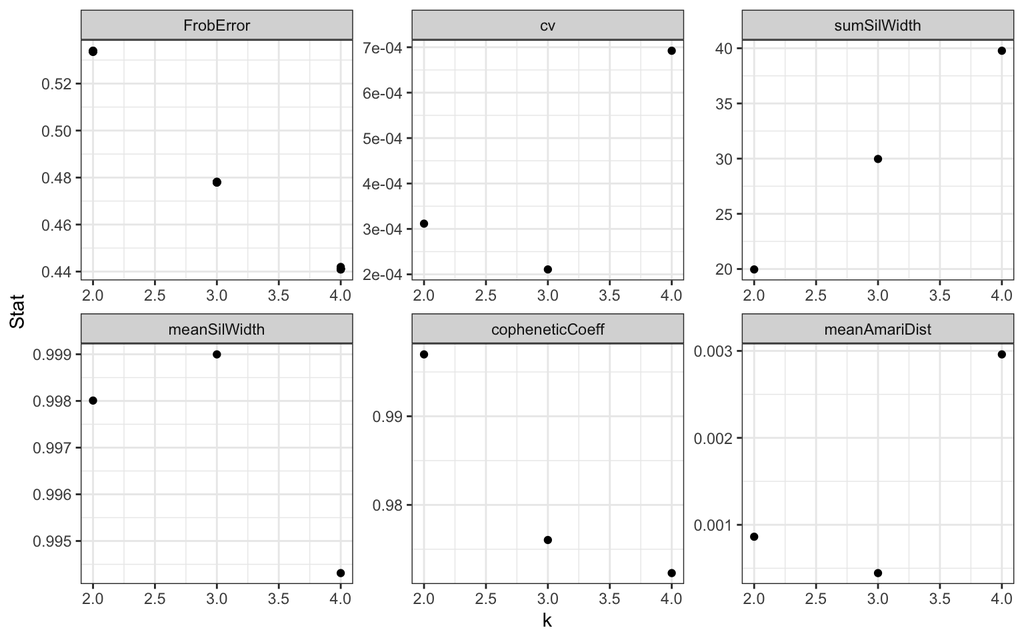

```r
gg_plotKStats(leukemia_nmf_exp)
```

## 3.3 Visualize the matrix H (exposures)

The matrices `H` may be visualized as heatmaps. We can define a meta information object and annotate meta data:

```r
heat_anno <- HeatmapAnnotation(df = leukemia$annotation[, c("ALL_AML", "Type")],
                               col = list(ALL_AML = c("ALL" = "grey80",
                                                      "AML" = "grey20"),
                                          Type = c("-" = "white",
                                                   "B-cell" = "grey80",
                                                   "T-cell" = "grey20")))
```

And now display the matrices `H` with meta data annotation:

```r
for(ki in k_min:k_max) {
  cat("\n")
  cat("  \n#### H matrix for k=",  ki, "   \n  ")
  #plot H matrix
  tmp_hmatrix <- HMatrix(leukemia_nmf_exp, k = ki)
  h_heatmap <- Heatmap(tmp_hmatrix,
                       col = viridis(100),
                       name = "Exposure",
                       clustering_distance_columns = 'pearson',
                       show_column_dend = TRUE,
                       top_annotation = heat_anno,
                       show_column_names = FALSE,
                       show_row_names = FALSE,
                       cluster_rows = FALSE)
  print(h_heatmap)
}
```

#### 3.3.0.1 H matrix for k= 2

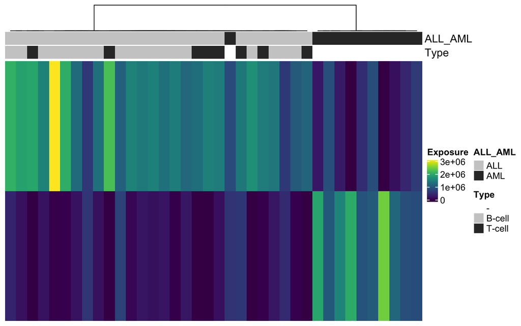

#### 3.3.0.2 H matrix for k= 3

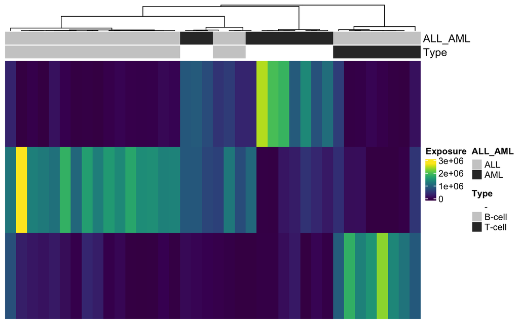

#### 3.3.0.3 H matrix for k= 4

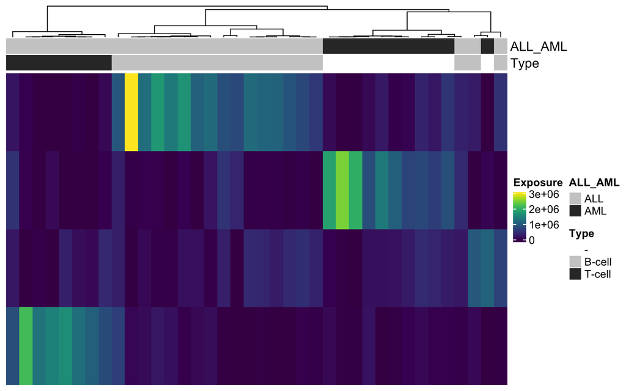

## 3.4 Feature selection

### 3.4.1 Row K-means to determine signature specific features

```r
### Find representative regions.
# Get W for best K
leukemia_features <- SignatureSpecificFeatures(leukemia_nmf_exp,
                                               k = 4,
                                               return_all_features = TRUE)
colnames(leukemia_features) <- paste0("Sign.", 1:4)
kable(head(leukemia_features))
```

|  | Sign.1 | Sign.2 | Sign.3 | Sign.4 |
| --- | --- | --- | --- | --- |
| A2M | 1 | 1 | 0 | 1 |
| AADAC | 0 | 0 | 1 | 0 |
| AARS | 1 | 0 | 0 | 1 |
| ABAT | 0 | 0 | 1 | 0 |
| ABCA3 | 0 | 1 | 1 | 0 |
| ABCA4 | 0 | 0 | 1 | 0 |

### 3.4.2 Feature visualization

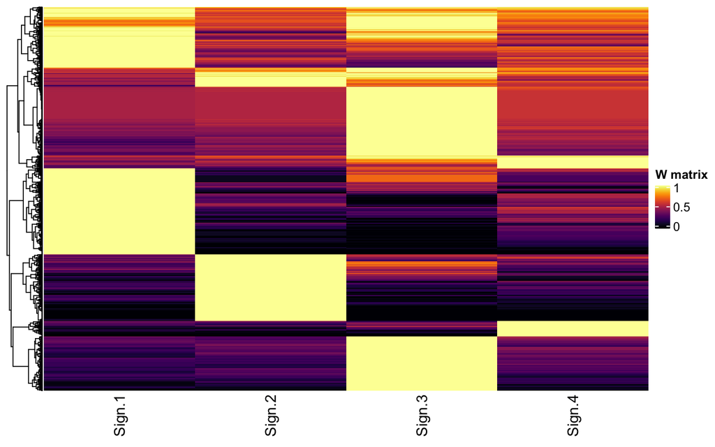

```r
# List of signature specific features
# leukemia_specific <- SignatureSpecificFeatures(leukemia_nmf_exp,
#                                                k = 4,
#                                                return_all_features = FALSE)


leukemia_specific <- rownames(leukemia_features)[rowSums(leukemia_features) == 1]
leukemia_Wspecific <- WMatrix(leukemia_nmf_exp, k = 4)[leukemia_specific, ]
colnames(leukemia_Wspecific) <- paste0("Sign.", 1:4)

# normalize exposure score in W matrix across rows
leukemia_Wspecific <- as.data.frame(leukemia_Wspecific) %>%
  rownames_to_column("GeneID") %>%
  pivot_longer(-GeneID, names_to = "SignatureID", values_to = "exposure") %>%
  group_by(GeneID) %>%
  mutate(exposure = exposure/max(exposure)) %>%
  pivot_wider(id_cols = GeneID, names_from = "SignatureID", values_from = "exposure") %>%
  column_to_rownames("GeneID") %>%
  as.matrix()



# Display selected features on W matrix
w_heatmap <- Heatmap(leukemia_Wspecific,
                     col = inferno(100),
                     name = "W matrix",
                     clustering_distance_columns = 'pearson',
                     show_column_dend = TRUE,
                     show_column_names = TRUE,
                     show_row_names = FALSE,
                     cluster_rows = TRUE,
                     cluster_columns = FALSE)
w_heatmap
```

```r
Sys.sleep(60)
```

# References

Alexandrov, LB, S Nik-Zainal, DC Wedge, SA Aparicio, S Behjati, AV Biankin, GR Bignell, et al. 2013. “Signatures of Mutational Processes in Cancer.” *Nature*. Nature Publishing Group.

Brunet, Jean-Philippe, Pablo Tamayo, Todd R. Golub, and Jill P. Mesirov. 2003. “Metagenes and Molecular Pattern Discovery Using Matrix Factorization.” *PNAS*. PNAS.

Gaujoux, Renaud, and Cathal Seoighe. 2010. “A Flexible R Package for Nonnegative Matrix Factorization.” *BMC Bioinformatics*. BMC.

Lee, Daniel D., and Sebastian Seung. 1999. “Learning the Parts of Objects by Non-Negative Matrix Factorization.” *Nature*. Nature Publishing Group.

Mejia-Roa, Edgardo, Daniel Tabas-Madrid, Javier Setoain, Carlos Garcia, Francisco Tirado, and Alberto Pascual-Montano. 2015. “NMF-mGPU: Non-Negative Matrix Factorization on Multi-GPU Systems.” *BMC Bioinformatics*. BMC.